# Analiza wyników i przewagi własnego boiska w meczach Ekstraklasy (1927-2025)

Weronika Czyż

2026-01-15

## Wprowadzenie

Zbiór danych zawiera 19232 rekordy z 10 atrybutami typu kategorycznego, numerycznego, porządkowego i binarnego.Każdy wpis z wybranego przeze mnie zbioru danych przedstawia rozegrany mecz Ekstraklasy.

## Zmienne

- Kolejka (porządkowe)
- Sezon (numeryczne)
- Drużyna gospodarzy (tekst, nazwa drużyny)
- Drużyna gości (tekst, nazwa drużyny)
- Data (czasowe)
- Godzina (czasowe)
- Gole gospodarzy (numeryczne)
- Gole gości (numeryczne)
- Czy odwołany (binarne, 0=nie, 1=tak)
- Czy walkower (binarne, 0=nie, 1=tak)

# Wykorzystane pakiety

```r
library(tidyverse)
library(lubridate)
library(mice)
library(dplyr)
library(ggplot2)
library(knitr)
library(psych)
```

## Wczytanie danych

```r
ekstraklasa <- read.csv("poland_2.csv", stringsAsFactors = FALSE, fileEncoding = "Latin2")
```

```r
head(ekstraklasa,5)
```

```
##   X Kolejka season           home                  away     date  hour gh ga
## 1 0       1   1927 1. FC Katowice          Ruch Chorzów 4/3/1927 16:00  7  0
## 2 1       1   1927   Warta Poznań           Czarni Lwów 4/3/1927 16:00  0  3
## 3 2       1   1927      TKS Toruń      Polonia Warszawa 4/3/1927 15:00  4  3
## 4 3       1   1927 Legia Warszawa Warszawianka Warszawa 4/3/1927 15:30  1  4
## 5 4       1   1927     Pogoń Lwów         Hasmonea Lwów 4/3/1927 15:30  7  1
##   IsCancelled IsWalkover
## 1           0          0
## 2           0          0
## 3           0          0
## 4           0          0
## 5           1          0
```

```r
tail(ekstraklasa,5)
```

```
##           X Kolejka    season              home           away      date  hour
## 19228 19227      18 2025/2026     Piast Gliwice Legia Warszawa 12/6/2025 20:15
## 19229 19228      18 2025/2026          Cracovia    Lech Poznań 12/7/2025 14:45
## 19230 19229      18 2025/2026       Arka Gdynia   Motor Lublin 12/6/2025 12:15
## 19231 19230      18 2025/2026 Raków Częstochowa   GKS Katowice 12/7/2025 17:30
## 19232 19231      18 2025/2026     Korona Kielce    Wisła Płock 12/8/2025 19:00
##       gh ga IsCancelled IsWalkover
## 19228  2  0           0          0
## 19229  2  2           0          0
## 19230  1  0           0          0
## 19231  1  0           0          0
## 19232  1  1           0          0
```

```r
str(ekstraklasa)
```

```
## 'data.frame':    19232 obs. of  11 variables:
##  $ X          : int  0 1 2 3 4 5 6 7 8 9 ...
##  $ Kolejka    : int  1 1 1 1 1 1 1 2 2 2 ...
##  $ season     : chr  "1927" "1927" "1927" "1927" ...
##  $ home       : chr  "1. FC Katowice" "Warta Poznań" "TKS Toruń" "Legia Warszawa" ...
##  $ away       : chr  "Ruch Chorzów" "Czarni Lwów" "Polonia Warszawa" "Warszawianka Warszawa" ...
##  $ date       : chr  "4/3/1927" "4/3/1927" "4/3/1927" "4/3/1927" ...
##  $ hour       : chr  "16:00" "16:00" "15:00" "15:30" ...
##  $ gh         : int  7 0 4 1 7 0 0 2 4 3 ...
##  $ ga         : int  0 3 3 4 1 2 4 1 2 1 ...
##  $ IsCancelled: int  0 0 0 0 1 0 0 0 0 0 ...
##  $ IsWalkover : int  0 0 0 0 0 0 0 0 0 0 ...
```

## Braki danych

```
##  /\     /\
## {  `---'  }
## {  O   O  }
## ==>  V <==  No need for mice. This data set is completely observed.
##  \  \|/  /
##   `-----'
```

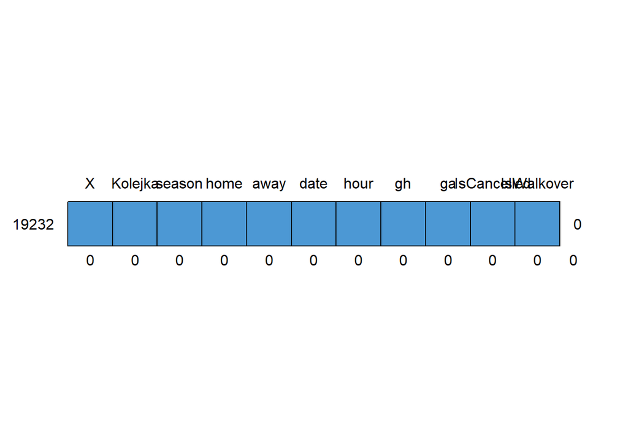

```
##       X Kolejka season home away date hour gh ga IsCancelled IsWalkover
## 19232 1       1      1    1    1    1    1  1  1           1          1 0
##       0       0      0    0    0    0    0  0  0           0          0 0
```

```r
md.pattern(ekstraklasa)
```

W zestawie nie występują braki danych.

## Czyszczenie danych

Zmieniam typ zmiennych tam gdzie jest to konieczne, aby usprawnić strukturę

```r
ekstraklasa <- ekstraklasa %>%
  mutate(
    data = as.Date(date, format = "%d/%m/%Y"),
    sezon = as.factor(season),
    kolejka = as.numeric(Kolejka),
    gole_gospodarzy = as.numeric(gh),
    gole_gosci = as.numeric(ga),
    anulowany = as.logical(IsCancelled),
    walkower = as.logical(IsWalkover)
  ) %>%
  filter(!anulowany, !walkower) %>%
  mutate(
    suma_goli = gole_gospodarzy + gole_gosci,
    roznica_goli = gole_gospodarzy - gole_gosci,
    dekada = floor(year(data) / 10) * 10,
    miesiac = month(data))
```

```r
summary(ekstraklasa)
```

```
##        X            Kolejka         season              home
##  Min.   :    0   Min.   : 1.00   Length:19118       Length:19118
##  1st Qu.: 4865   1st Qu.: 8.00   Class :character   Class :character
##  Median : 9648   Median :15.00   Mode  :character   Mode  :character
##  Mean   : 9651   Mean   :15.57
##  3rd Qu.:14447   3rd Qu.:23.00
##  Max.   :19231   Max.   :44.00
##
##      away               date               hour                 gh
##  Length:19118       Length:19118       Length:19118       Min.   : 0.000
##  Class :character   Class :character   Class :character   1st Qu.: 1.000
##  Mode  :character   Mode  :character   Mode  :character   Median : 1.000
##                                                           Mean   : 1.606
##                                                           3rd Qu.: 2.000
##                                                           Max.   :15.000
##
##        ga         IsCancelled   IsWalkover      data
##  Min.   :0.000   Min.   :0    Min.   :0    Min.   :1927-01-05
##  1st Qu.:0.000   1st Qu.:0    1st Qu.:0    1st Qu.:1969-09-04
##  Median :1.000   Median :0    Median :0    Median :1990-01-04
##  Mean   :1.044   Mean   :0    Mean   :0    Mean   :1986-11-09
##  3rd Qu.:2.000   3rd Qu.:0    3rd Qu.:0    3rd Qu.:2008-11-04
##  Max.   :8.000   Max.   :0    Max.   :0    Max.   :2025-12-09
##                                            NA's   :11916
##        sezon          kolejka      gole_gospodarzy    gole_gosci
##  1991/1992:  306   Min.   : 1.00   Min.   : 0.000   Min.   :0.000
##  1993/1994:  306   1st Qu.: 8.00   1st Qu.: 1.000   1st Qu.:0.000
##  1994/1995:  306   Median :15.00   Median : 1.000   Median :1.000
##  1995/1996:  306   Mean   :15.57   Mean   : 1.606   Mean   :1.044
##  1997/1998:  306   3rd Qu.:23.00   3rd Qu.: 2.000   3rd Qu.:2.000
##  2021/2022:  306   Max.   :44.00   Max.   :15.000   Max.   :8.000
##  (Other)  :17282
##  anulowany        walkower         suma_goli       roznica_goli
##  Mode :logical   Mode :logical   Min.   : 0.000   Min.   :-8.000
##  FALSE:19118     FALSE:19118     1st Qu.: 1.000   1st Qu.: 0.000
##                                  Median : 2.000   Median : 0.000
##                                  Mean   : 2.649   Mean   : 0.562
##                                  3rd Qu.: 4.000   3rd Qu.: 2.000
##                                  Max.   :15.000   Max.   :15.000
##
##      dekada         miesiac
##  Min.   :1920    Min.   : 1.000
##  1st Qu.:1960    1st Qu.: 4.000
##  Median :1990    Median : 7.000
##  Mean   :1982    Mean   : 6.535
##  3rd Qu.:2000    3rd Qu.:10.000
##  Max.   :2020    Max.   :12.000
##  NA's   :11916   NA's   :11916
```

```r
ekstraklasa %>%
  select(gole_gospodarzy, gole_gosci, sezon) %>%
  describe()
```

```
##                 vars     n  mean    sd median trimmed   mad min max range  skew
## gole_gospodarzy    1 19118  1.61  1.42      1    1.43  1.48   0  15    15  1.26
## gole_gosci         2 19118  1.04  1.11      1    0.87  1.48   0   8     8  1.28
## sezon*             3 19118 53.54 25.02     56   54.88 29.65   1  92    91 -0.35
##                 kurtosis   se
## gole_gospodarzy     2.98 0.01
## gole_gosci          2.13 0.01
## sezon*             -0.86 0.18
```

## Problem 1: Przewaga własnego boiska

Jakie znaczenie na przestrzeni dekad miało rozgrywanie meczu na swoim boisku, przed swoją publicznością?

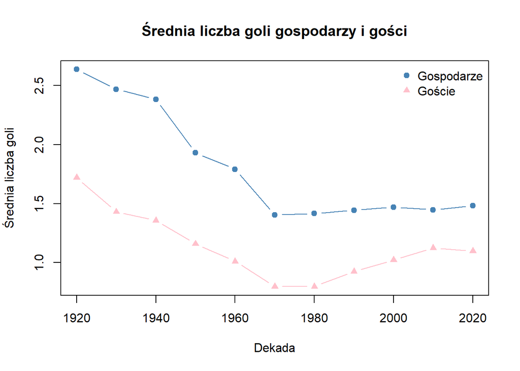

```r
dane_dekady <- ekstraklasa %>%
  group_by(dekada) %>%
  summarise(gole_gosp = mean(gole_gospodarzy, na.rm = TRUE),
            gole_gosc = mean(gole_gosci, na.rm = TRUE))

plot(dane_dekady$dekada, dane_dekady$gole_gosp,
     type = "b",
     pch = 19,
     col = "steelblue",
     ylim = range(dane_dekady[, 2:3]),
     xlab = "Dekada",
     ylab = "Średnia liczba goli",
     main = "Średnia liczba goli gospodarzy i gości")

lines(dane_dekady$dekada,
      dane_dekady$gole_gosc,
      type = "b",
      pch = 17,
      col = "pink")
legend(  "topright",
         legend = c("Gospodarze", "Goście"),
         col = c("steelblue", "pink"),
         pch = c(19, 17),
         bty = "n")
```

Możemy odczytać z wykresu, że na przestrzeni dekad gospodarze przeciętnie zdobywali więcej bramek niż drużyny gości, co wskazuje na istnienie przewagi własnego boiska. Różnica nie jest jednak stała w czasie, czyli jej skala zmienia się wraz z ewolucją ligi.

## Problem 2: Zmiany liczby bramek na mecz w czasie

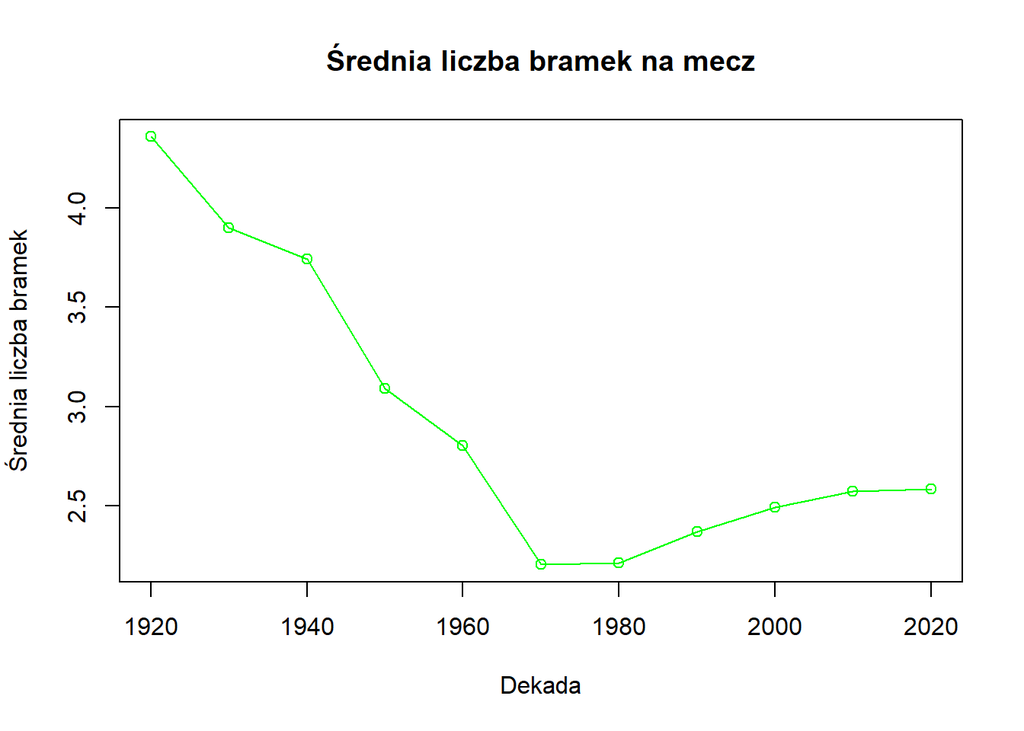

```r
srednia_goli <- ekstraklasa %>%
  group_by(dekada) %>%
  summarise(suma_goli = mean(suma_goli, na.rm = TRUE))

plot(srednia_goli$dekada, srednia_goli$suma_goli,
     type = "o",
     col = "green",
     xlab = "Dekada",
     ylab = "Średnia liczba bramek",
     main = "Średnia liczba bramek na mecz")
```

Z wykresu dowiadujemy się, że początki Ekstraklasy były znacznie obfitsze w bramki niż w ostatnich dekadach. Może to świadczyć o zmianach stylu gry lub / i regulaminów rozgrywek. Ekstraklasa stała się ligą bardziej defensywną niż na początku. Ciekawy jest też pewien moment widoczny dobrze na wykresie - w okolicach lat 70 średnia liczba bramek osiągneła swoje minimum, po czym z dekady na dekade zaczęła wzrastać. Było to zbieżne ze światowymi trendami rygorystycznej obrony.